# Plots of model fit for all 16 models, for all 3 pgroups, for Bramley+Droop CESM function

#### A panel splitting out observed v observed, for the full model

This is the two-panel plot split for Effect, for the full model, to compare structures where E=0 with E=1:

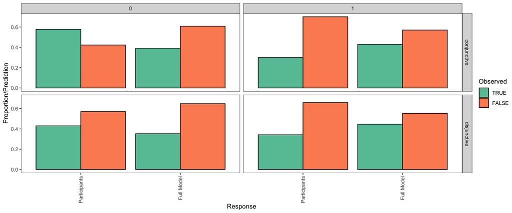

#### The next two chunks make a plot for noKind for unobserved v Effect

I was thinking I should report noKind because its unobserved are more ‘honest’ since they are not stretched by the parameter kappa. But I should still do the full one afterwards.

This is unobserved v observed two-panel plot for the noKind model, ie. the full model but without Kindness:

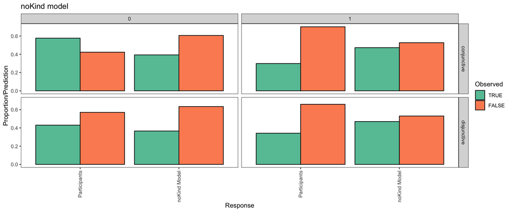

#### The next two chunks make a plot for noSelect v Effect

We should also try noSelect! Here goes:

This is unobserved v observed two-panel plot for the noSelect model, ie. the full model but without CESM causal selection:

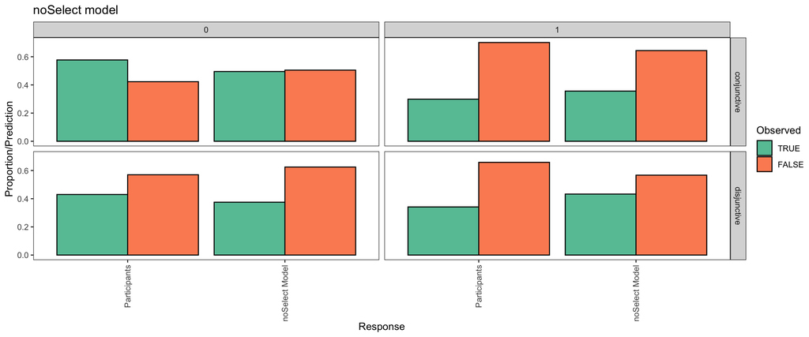

### A section of plots for simple 111s for a few different models: full, noSelect, noKind

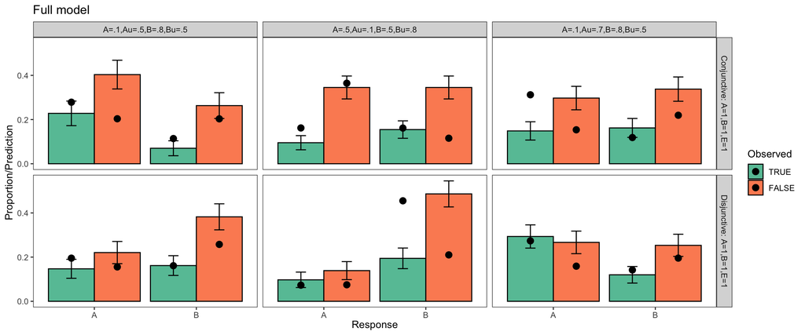

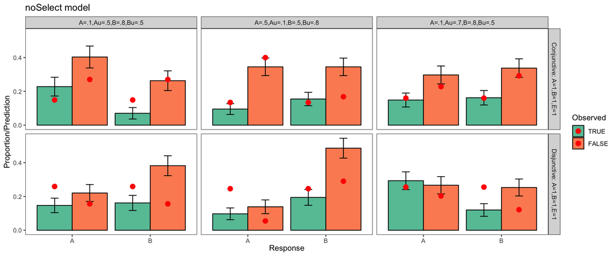

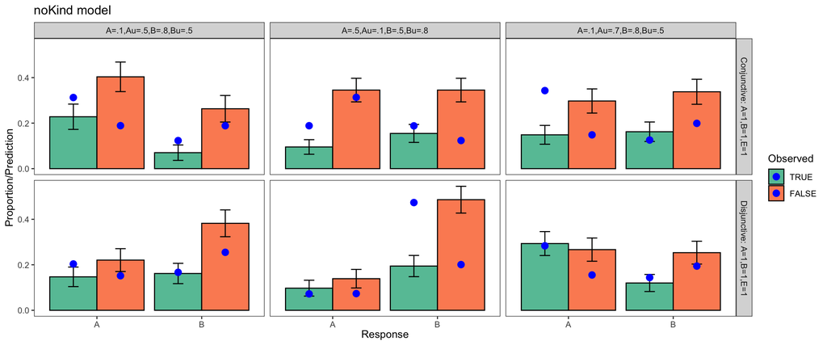

### Compound decision

Did they suggest A or B?

Same split as above but for Variable only:

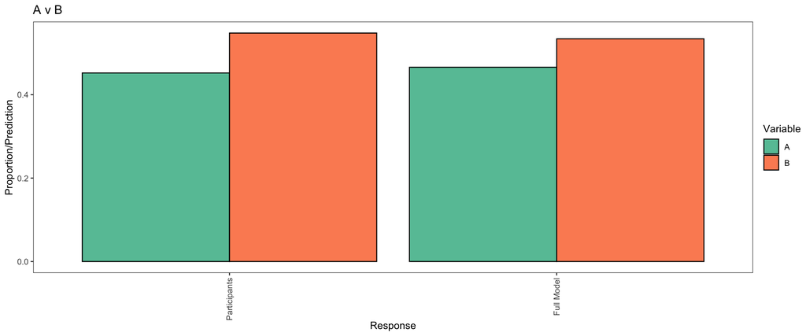

Now we want a chart like the 111 one, but for a compound decision for AvB. This will split the complex disjunction of two conjunctions up. FULLMODEL

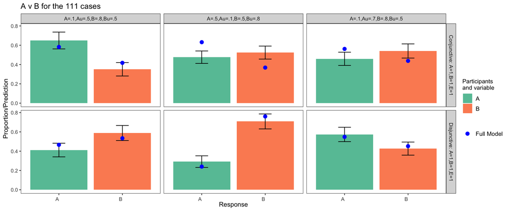

Then just the same, but for noSelect

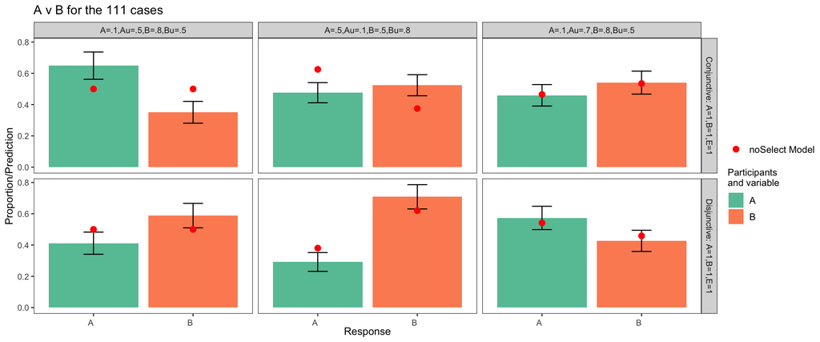

NOTE: WHEN I WANT TO PUT THESE IN THE GITHUB README, CONVERT TO PNG OR JPEG FIRST THEN EMBED IN HTML OR MKD - it won’t do pdf